# Are We Just Lucky or Did We Have Help?

The question I aim to explore is: given the demographics and background of students, can we predict how successful they will be in school? What truly fosters academic success?

If we could reliably predict student outcomes based on quantifiable data, what would that say about those who excel despite the odds—or those who falter despite every advantage? Understanding these dynamics isn’t about labeling students, but about uncovering what factors truly influence success. If we can identify them, maybe we can help more students reach their potential.

# Our class

This dataset comes from the UCI Machine Learning Repository (Cortez, 2008) and includes data from two secondary schools in Portugal. It contains demographic and social information such as sex, age, address type, and family size, among others. In total, there are 30 features describing various student characteristics and background factors. The final three columns represent the students’ grades in the first period, second period, and final term, which serve as the primary indicators of academic performance.

Feature List

1. school – Student’s school (binary: 'GP' = Gabriel Pereira or 'MS' = Mousinho da Silveira)
2. sex – Student’s sex (binary: 'F' = female or 'M' = male)
3. age – Student’s age (numeric: 15–22)
4. address – Home address type (binary: 'U' = urban or 'R' = rural)
5. famsize – Family size (binary: 'LE3' = ≤3 or 'GT3' = >3)
6. Pstatus – Parent’s cohabitation status (binary: 'T' = living together or 'A' = apart)

Parental and Family Information

7. Medu – Mother’s education (numeric: 0 = none, 1 = primary, 2 = 5th–9th grade, 3 = secondary, 4 = higher)
8. Fedu – Father’s education (same scale as above)
9. Mjob – Mother’s job (teacher, health, services, at_home, other)
10. Fjob – Father’s job (teacher, health, services, at_home, other)
11. reason – Reason for choosing this school (close_to_home, reputation, course, other)
12. guardian – Student’s guardian (mother, father, other)

Study and Academic Information

13. traveltime – Home-to-school travel time (1 = <15 min, 2 = 15–30 min, 3 = 30–60 min, 4 = >60 min)
14. studytime – Weekly study time (1 = <2 hrs, 2 = 2–5 hrs, 3 = 5–10 hrs, 4 = >10 hrs)
15. failures – Number of past class failures (numeric: 0–3)
16. schoolsup – Extra educational support (binary: yes/no)
17. famsup – Family educational support (binary: yes/no)
18. paid – Extra paid classes within the course subject (Math or Portuguese) (binary: yes/no)
19. activities – Extracurricular activities (binary: yes/no)
20. nursery – Attended nursery school (binary: yes/no)
21. higher – Wants to take higher education (binary: yes/no)

Social, Lifestyle, and Well-being

Target Variables

31. G1 – First-period grade (numeric: 0–20)
32. G2 – Second-period grade (numeric: 0–20)
33. G3 – Final grade (numeric: 0–20)

```python
import pandas as pd
import matplotlib.pyplot as plt
import numpy as np
import statsmodels.api as sm
```

# First Day of class

In this step, I imported the dataset and examined its structure. Since the dataset uses semicolons (;) as delimiters, I had to specify this during import to ensure that all columns were parsed correctly.

```python
students = pd.read_csv("../data/student-por.csv",sep=';')
students.head()
```

|  | school | sex | age | address | famsize | Pstatus | Medu | Fedu | Mjob | Fjob | ... | famrel | freetime | goout | Dalc | Walc | health | absences | G1 | G2 | G3 |
| --- | --- | --- | --- | --- | --- | --- | --- | --- | --- | --- | --- | --- | --- | --- | --- | --- | --- | --- | --- | --- | --- |
| 0 | GP | F | 18 | U | GT3 | A | 4 | 4 | at_home | teacher | ... | 4 | 3 | 4 | 1 | 1 | 3 | 4 | 0 | 11 | 11 |
| 1 | GP | F | 17 | U | GT3 | T | 1 | 1 | at_home | other | ... | 5 | 3 | 3 | 1 | 1 | 3 | 2 | 9 | 11 | 11 |
| 2 | GP | F | 15 | U | LE3 | T | 1 | 1 | at_home | other | ... | 4 | 3 | 2 | 2 | 3 | 3 | 6 | 12 | 13 | 12 |
| 3 | GP | F | 15 | U | GT3 | T | 4 | 2 | health | services | ... | 3 | 2 | 2 | 1 | 1 | 5 | 0 | 14 | 14 | 14 |
| 4 | GP | F | 16 | U | GT3 | T | 3 | 3 | other | other | ... | 4 | 3 | 2 | 1 | 2 | 5 | 0 | 11 | 13 | 13 |

5 rows × 33 columns

# Sharpen your pencils

Before diving into analysis, it’s important to make sure everything was imported correctly. Using shape() confirms that the full dataset loaded — the expected number of rows and columns. If the dimensions don’t match what’s documented, that’s the first red flag.

Next, info() gives a quick rundown of what I’m actually working with. It lists each column, the data type, and how many values are missing. This helps identify which features are numerical (usable in regression right away) and which are categorical or incomplete and will need cleaning or encoding later.

The data looks intact, and there are no null values. Right off the bat, I’ll be dropping the following features: reason, G1, and G2.

I’m removing reason because it’s redundant — the student is already enrolled, so understanding why they chose the school adds little value compared to what the school feature already represents.

G1 and G2 (first and second period grades) are being dropped because they would overfit the model. These variables are highly correlated with the final grade (G3), which would inflate accuracy without providing new insight. Since my goal is to understand how demographic and social factors influence final performance, keeping these would undermine that purpose.

```python
print(f"Rows and Columns: {students.shape}")
students.info()
```

```
Rows and Columns: (649, 33)
<class 'pandas.core.frame.DataFrame'>
RangeIndex: 649 entries, 0 to 648
Data columns (total 33 columns):
 #   Column      Non-Null Count  Dtype
---  ------      --------------  -----
 0   school      649 non-null    object
 1   sex         649 non-null    object
 2   age         649 non-null    int64
 3   address     649 non-null    object
 4   famsize     649 non-null    object
 5   Pstatus     649 non-null    object
 6   Medu        649 non-null    int64
 7   Fedu        649 non-null    int64
 8   Mjob        649 non-null    object
```

[output cut: 26 more lines]

# Janitor please report to the Hallway

Before dropping features, I want to make sure the dataset is clean and free of duplicates. Duplicate rows can skew results and introduce bias into the model, especially when working with relatively small datasets like this one.

Using duplicated().sum() gives a quick count of any repeated entries, allowing me to verify whether each student record is unique.

```python
students.duplicated().sum()
```

```
np.int64(0)
```

# Hallway Clear

Verified that there are no duplicate entries — each row represents a unique student record. With the dataset confirmed clean, I can now drop the three previously identified features: reason, G1, and G2.

```python
students.drop(['reason','G1','G2'], axis=1, inplace=True)
students.shape
```

```
(649, 30)
```

# Role call!

Now it’s time to convert the categorical values into numerical ones. Linear regression requires all features to be numeric, so any text-based data needs to be translated into a format the model can understand.

The first step is to identify which columns are categorical. This helps make sure I don’t accidentally convert numeric features or miss anything important. Once identified, I’ll apply one-hot encoding to create dummy variables for each category, allowing the model to interpret these features properly.

```python
students.select_dtypes(include='object').columns
```

```
Index(['school', 'sex', 'address', 'famsize', 'Pstatus', 'Mjob', 'Fjob',
       'guardian', 'schoolsup', 'famsup', 'paid', 'activities', 'nursery',
       'higher', 'internet', 'romantic'],
      dtype='object')
```

# Hot potato!

Before applying one-hot encoding, I want to see what each categorical feature looks like and how many unique values it contains. This helps me predict how many new columns encoding will generate and verify that I understand the dataset’s structure before transforming it.

From inspection, most features such as sex, school, internet, and romantic are binary, meaning they will each produce one new column when encoded with drop_first=True. However, a few features — specifically Mjob, Fjob, and guardian — have multiple categories, which means they will expand into several columns. For example:

- Mjob and Fjob each have 5 unique categories, resulting in 4 new columns each after dropping one baseline.
- guardian has 3 categories, resulting in 2 new columns.

Adding those up, I expect roughly 7 new columns after encoding (4 + 4 + 2 + 13 binary columns = 23 total, minus 16 dropped baselines). This quick estimation step ensures I know exactly how much my dataset will grow — and confirms later that pandas didn’t silently drop or misencode anything.

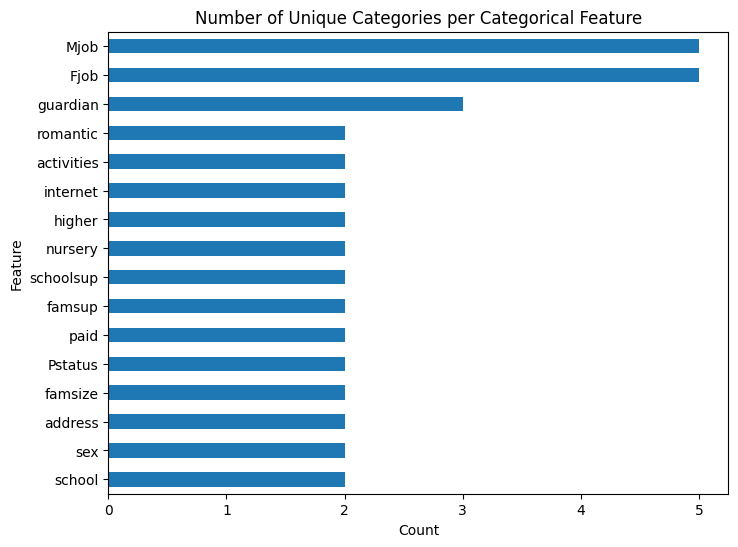

```python
cat_cols = students.select_dtypes(include='object').columns
students[cat_cols].nunique().sort_values().plot(kind='barh', figsize=(8,6))
plt.title("Number of Unique Categories per Categorical Feature")
plt.xlabel("Count")
plt.ylabel("Feature")
plt.show()
```

# New seating arrangement

Here I encode the identified categorical columns into numerical ones. This step translates the text-based data into a form the model can understand.

This process is called one-hot encoding — it converts each category into its own column filled with 1s and 0s, representing True or False for whether that category applies to a given student. For example, a feature like address with values U (urban) and R (rural) becomes two binary columns: address_U and address_R, where 1 means the student lives in that type of area and 0 means they don’t.

This ensures the model treats categories as distinct rather than ordered — “urban” isn’t greater or less than “rural,” just different.

```python
students_encoded = pd.get_dummies(students, drop_first = True)

students_encoded.info()
```

```
<class 'pandas.core.frame.DataFrame'>
RangeIndex: 649 entries, 0 to 648
Data columns (total 37 columns):
 #   Column           Non-Null Count  Dtype
---  ------           --------------  -----
 0   age              649 non-null    int64
 1   Medu             649 non-null    int64
 2   Fedu             649 non-null    int64
 3   traveltime       649 non-null    int64
 4   studytime        649 non-null    int64
 5   failures         649 non-null    int64
 6   famrel           649 non-null    int64
 7   freetime         649 non-null    int64
 8   goout            649 non-null    int64
 9   Dalc             649 non-null    int64
```

[output cut: 29 more lines]

# New students! bring me more chairs!

After encoding, my estimate was correct — 7 new columns were added. This confirmed that the majority of features were binary, with only a few multi-category ones (Mjob, Fjob, guardian). The result matches the prediction that one-hot encoding with drop_first=True would expand the dataset modestly rather than explosively.

This is a good checkpoint because it shows that the encoding worked exactly as expected and that no categories were silently dropped. This kind of validation ensures that every categorical feature contributes meaningfully to the model without creating redundant or collinear columns.

# Wait a minute, can I see your schedule?

While using drop_first=True during one-hot encoding helps prevent redundant columns in binary features (like yes/no or male/female), it doesn’t completely eliminate the risk of multicollinearity. Multicollinearity happens when two or more features are so closely related that one can be almost perfectly predicted by another. In linear regression, this causes unstable coefficients and makes it hard to determine which variable is actually influencing the outcome.

To test for this, I used Variance Inflation Factor (VIF) through the statsmodels library. VIF measures how much a variable’s variance is inflated because of its correlation with other predictors. Simply — it checks whether some features are just saying the same thing in different ways.

The rule of thumb:

VIF ≈ 1–5 → Safe, minimal correlation

VIF 5–10 → Moderate correlation, worth a look

VIF > 10 → Strong correlation, likely redundant

Running the VIF analysis confirmed that all features are within a safe range (no values above 5), meaning none of the encoded variables are stepping on each other’s toes. The dataset is clean and ready for regression modeling without any risk of inflated variance or unstable coefficients.

```python
from statsmodels.stats.outliers_influence import variance_inflation_factor

X = students_encoded.drop(columns=['G3'], errors='ignore')

# convert bool to int (True = 1, False = 0)
X = X.astype({col: 'int64' for col in X.select_dtypes('bool').columns})

# ensure everything else is numeric
X = X.apply(pd.to_numeric, errors='coerce')

# add intercept
X_const = sm.add_constant(X)

# compute VIF
vif = pd.DataFrame({
    'Feature': X_const.columns,
    'VIF': [variance_inflation_factor(X_const.values, i) for i in range(X_const.shape[1])]
})

vif.sort_values(by='VIF', ascending=False)
```

|  | Feature | VIF |
| --- | --- | --- |
| 0 | const | 359.082147 |
| 24 | Fjob_other | 4.643069 |
| 25 | Fjob_services | 4.197478 |
| 2 | Medu | 2.681561 |
| 22 | Mjob_teacher | 2.265079 |
| 26 | Fjob_teacher | 2.151558 |
| 11 | Walc | 2.099200 |
| 21 | Mjob_services | 2.097173 |
| 3 | Fedu | 2.092338 |
| 20 | Mjob_other | 1.989999 |
| 19 | Mjob_health | 1.793102 |
| 10 | Dalc | 1.791626 |
| 23 | Fjob_health | 1.743255 |
| 28 | guardian_other | 1.524943 |
| 9 | goout | 1.453917 |
| 14 | school_MS | 1.432090 |
| 1 | age | 1.406408 |
| 15 | sex_M | 1.372348 |
| 27 | guardian_mother | 1.343207 |
| 6 | failures | 1.319251 |
| 16 | address_U | 1.299881 |
| 4 | traveltime | 1.280029 |
| 34 | higher_yes | 1.268903 |
| 8 | freetime | 1.267797 |
| 35 | internet_yes | 1.241852 |
| 5 | studytime | 1.208025 |
| 13 | absences | 1.205610 |
| 18 | Pstatus_T | 1.183604 |
| 17 | famsize_LE3 | 1.137503 |
| 29 | schoolsup_yes | 1.129018 |
| 7 | famrel | 1.121216 |
| 30 | famsup_yes | 1.120638 |
| 36 | romantic_yes | 1.109129 |
| 12 | health | 1.108571 |
| 32 | activities_yes | 1.107362 |
| 31 | paid_yes | 1.085097 |
| 33 | nursery_yes | 1.064289 |

# Class is in Session, Lets Split Up Into Groups

Time to divide and conquer. To properly evaluate how well the model performs, the dataset needs to be split into two parts:

Training set (80%) — where the model learns the relationships between features and the target variable.

Testing set (20%) — where the model is graded on data it hasn’t seen before.

This prevents overfitting (the model memorizing the data instead of learning from it) and gives a realistic picture of how it will perform on new, unseen cases.

```python
from sklearn.model_selection import train_test_split, GridSearchCV, KFold

X = students_encoded.drop(columns=['G3'])
y = students_encoded['G3']

X_train, X_test, y_train, y_test = train_test_split(
    X, y, test_size=0.2, random_state=42
)

X_train.shape, X_test.shape, y_train.shape, y_test.shape
```

```
((519, 36), (130, 36), (519,), (130,))
```

# POP QUIZ!

### Experiment 1: Baseline minimal

Now I implement the linear regression model

```python
from sklearn.linear_model import LinearRegression
from sklearn.metrics import r2_score, mean_absolute_error, root_mean_squared_error

linreg = LinearRegression()
linreg.fit(X_train, y_train)

y_pred = linreg.predict(X_test)

r2 = r2_score(y_test, y_pred)
mae = mean_absolute_error(y_test, y_pred)
rmse = root_mean_squared_error(y_test, y_pred)

print(f"R²:   {r2:.3f}")
print(f"MAE:  {mae:.3f}")
print(f"RMSE: {rmse:.3f}")


coefs = pd.Series(linreg.coef_, index=X_train.columns).sort_values(ascending=False)

coefs.head(10), coefs.tail(10)
```

```
R²:   0.182
MAE:  2.128
RMSE: 2.824
```

```
(higher_yes        1.714610
 Mjob_health       1.103300
 guardian_other    0.577504
 Mjob_teacher      0.560830
 Mjob_services     0.505503
 studytime         0.399058
 internet_yes      0.303403
 Fedu              0.276127
 activities_yes    0.259115
 address_U         0.236051
 dtype: float64,
 romantic_yes    -0.421140
 Fjob_other      -0.482348
 sex_M           -0.491768
 paid_yes        -0.497741
 Fjob_teacher    -0.576896
 Fjob_health     -1.000306
 Fjob_services   -1.143561
 failures        -1.487629
 school_MS       -1.496438
 schoolsup_yes   -1.608555
 dtype: float64)
```

# Quiz results in!

We’ve got our model results — and it’s not looking great. R² is sitting at 18%, which means the model is barely explaining any of the variation in grades. In other words, it’s almost guessing.

What’s going on

I checked the coefficients to see which features were doing the heavy lifting, and found some questionable trends. Mjob_health popped up as a strong predictor, which is weird and worth digging into — it might be acting as a proxy for something else like parental education or socioeconomic status. Either way, that’s a red flag.

How bad is it really?

The MAE shows we’re off by about 2 points on average, and the RMSE around 3 points means those big misses happen fairly often. So even when it’s not totally wrong, it’s still pretty wrong.

Bottom line

The model isn’t performing well. It’s struggling to find meaningful patterns, and some features may be misleading it.

Below is a visualization of the findings and its saying try harder.

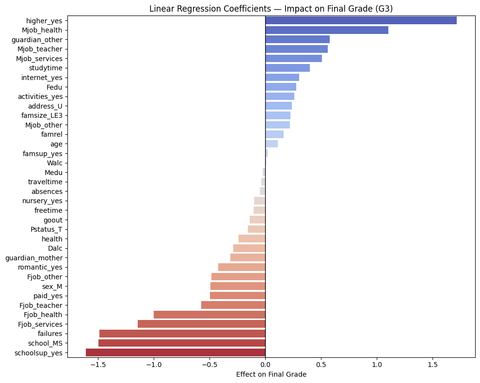

```python
import seaborn as sns

# Sort coefficients by magnitude
coef_df = pd.DataFrame({
    'Feature': X_train.columns,
    'Coefficient': linreg.coef_
}).sort_values(by='Coefficient', ascending=False)

plt.figure(figsize=(10,8))
sns.barplot(x='Coefficient', y='Feature', data=coef_df, hue='Feature',palette='coolwarm', dodge=False, legend=False)
plt.title('Linear Regression Coefficients — Impact on Final Grade (G3)')
plt.xlabel('Effect on Final Grade')
plt.ylabel('')
plt.axvline(0, color='black', linewidth=1)
plt.tight_layout()
plt.show()
```

## Bonus! Common Core Math (Linear Regression)

Linear regression is basically trying to draw the best possible line through the data — the one that minimizes how far off the predictions are from the actual grades.

We predict grades with:

$$ \hat{y} = \beta_0 + \beta_1x_1 + \beta_2x_2 + \dots + \beta_nx_n $$

The coefficients (the β’s) are just weights the model adjusts to make the line fit better. To find those, it minimizes something called the Sum of Squared Errors (SSE):

$$ SSE = \sum_{i=1}^{m}(y_i - \hat{y}_i)^2 $$

That’s just math-speak for “make the distance between prediction and reality as small as possible.”

Behind the scenes, it solves this with matrix algebra:

$$ \boldsymbol{\beta} = (X^TX)^{-1}X^Ty $$

That’s the Ordinary Least Squares (OLS) formula — the part that takes all your features, smashes them into a giant matrix, and spits out the line that best fits your data.

Where:

- ( X ) is the **feature matrix**
- ( y ) is the **target vector**

So, linear regression isn’t guessing. It’s doing a ton of math to find the most balanced set of coefficients that make your predictions suck the least.

# Hitting the Books

Not visualizing the data before feature selection came back to bite me. So now I’m taking a step back to see what’s actually going on.

Below are the distributions for mother’s and father’s jobs. I wanted to understand why Mjob_health ended up having such a huge impact. But looking at this… health is a tiny slice of the dataset. So why is it making such a big difference?

Something’s off here — either there’s hidden correlation (like education or income level tied to that category), or the model is overfitting to noise in a small subset. Either way, it’s worth digging deeper.

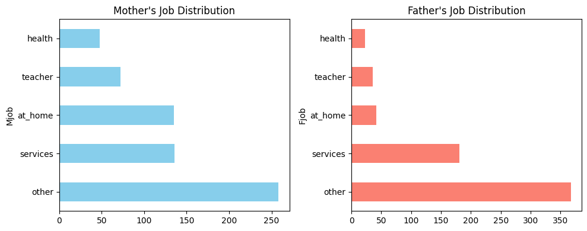

```python
fig, ax = plt.subplots(1, 2, figsize=(10, 4))

students['Mjob'].value_counts().plot(kind='barh', ax=ax[0], title="Mother's Job Distribution", color='skyblue')
students['Fjob'].value_counts().plot(kind='barh', ax=ax[1], title="Father's Job Distribution", color='salmon')

plt.tight_layout()
plt.show()
```

# The Math ain't Mathing

When I looked at the average final grades by mother’s job, things got even weirder.

That doesn’t add up. This probably means the model picked up on patterns tied to small sample noise or correlations with other variables like Medu (mother’s education). Basically, it’s seeing ghosts in the data.

```python
students.groupby('Mjob')['G3'].mean().sort_values(ascending=False)
```

```
Mjob
teacher     13.138889
health      13.062500
services    12.147059
other       11.670543
at_home     11.044444
Name: G3, dtype: float64
```

# Somone, get me a Calculator!

At this point, I wanted to see if there was something behind the “health” signal. Maybe moms in health-related jobs tend to have higher education levels — which could explain why the model latched onto it.

Turns out, that’s exactly what’s happening. When grouped by mother’s job, education levels (Medu) are highest for teachers and health professionals. So the model isn’t really rewarding “health” as a job — it’s rewarding education, but it’s expressing that relationship through the job category.

In other words: Mjob_health isn’t magical — it’s just wearing Medu’s hat.

```python
students.groupby("Mjob")["Medu"].mean().sort_values(ascending=False)
```

```
Mjob
teacher     3.958333
health      3.562500
services    2.801471
other       2.201550
at_home     1.681481
Name: Medu, dtype: float64
```

# New Formula unlocked!

Alright, time to check if mom’s education actually matters here. Sure enough, Medu and G3 show a mild positive correlation (~0.24). Not mind-blowing, but strong enough to move the needle.

So what looked like “health jobs = higher grades” is really just “higher-educated moms = higher grades.” The model’s not being smart — it’s just confusing cause with correlation.

```python
students[["Medu", "G3"]].corr()
```

|  | Medu | G3 |
| --- | --- | --- |
| Medu | 1.000000 | 0.240151 |
| G3 | 0.240151 | 1.000000 |

# Someone check on DAD!

Alright, before I go any further down the rabbit hole of mother-based predictors, I figured I should check in on the dads. Turns out… they’re barely in the picture.

Out of the whole dataset, mothers are listed as the primary guardian nearly three times as often as fathers, and “other” barely registers. So if the model’s leaning heavily on Mjob, it’s probably because the mom-related features are simply more represented — the dads just don’t have the same statistical weight to compete.

No wonder Fjob isn’t doing much — the data itself is saying, “Mom’s running the show.”

```python
students['guardian'].value_counts(normalize=True)
students['Fjob'].value_counts(normalize=True)
students[['guardian', 'Fjob']].groupby('guardian')['Fjob'].count()
```

```
guardian
father    153
mother    455
other      41
Name: Fjob, dtype: int64
```

# Geography Time!

I’m stepping back to examine the dataset as a whole to identify where the real “problem child” is hiding.

It turns out the issue isn’t the kids — it’s the parents. The Mjob_* and Fjob_* features are redundant and fragmented, forcing the model to assign meaning to tiny, unbalanced subcategories. This creates noise and encourages overfitting, as the model starts “hallucinating” importance in small, statistically weak groups.

To fix this, I’m consolidating these into two simple binary indicators:

Does mom have a job?

Does dad have a job?

This preserves the socioeconomic signal while removing ambiguity and redundant granularity.

Additionally, I identified right-skewed variables, particularly absences, which can distort regression coefficients and obscure linear relationships. To mitigate this, I applied a log transform to absences (np.log1p(absences)), compressing large outliers and improving linearity in the model.

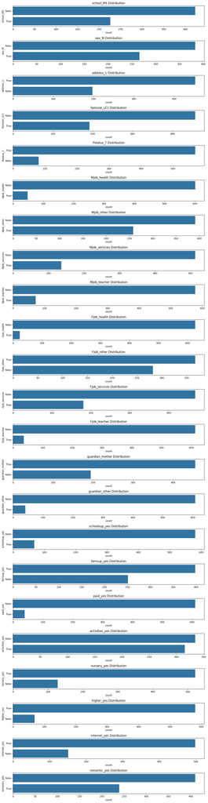

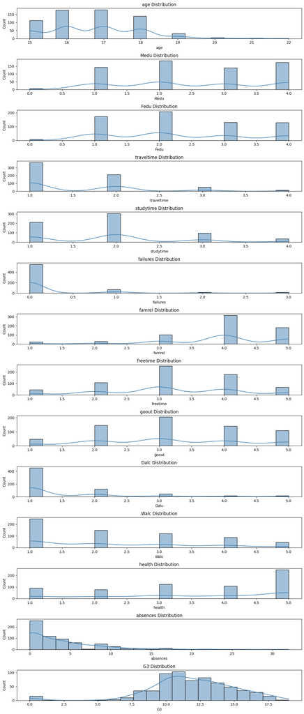

```python
# Separate categorical and numerical columns
cat_cols = students_encoded.select_dtypes(include=['object', 'category', 'bool']).columns
num_cols = students_encoded.select_dtypes(include=['int64', 'float64']).columns

fig, axes = plt.subplots(nrows=len(cat_cols), ncols=1, figsize=(12, len(cat_cols)*2))
for i, col in enumerate(cat_cols):
    sns.countplot(y=col, data=students_encoded, order=students_encoded[col].value_counts().index, ax=axes[i], hue=None)
    axes[i].set_title(f'{col} Distribution')
plt.tight_layout()
plt.show()

# numerical
fig, axes = plt.subplots(nrows=len(num_cols), ncols=1, figsize=(12, len(num_cols)*2))
for i, col in enumerate(num_cols):
    sns.histplot(students[col], kde=True, bins=20, color='steelblue', ax=axes[i])
    axes[i].set_title(f'{col} Distribution')
plt.tight_layout()
plt.show()
```

# Calling Mr. Jones .....

It turns out that while fathers are often present in the family unit, mothers are listed as the primary guardian most of the time. There’s no direct data to prove why, but it’s likely because mothers are the ones handling day-to-day logistics — like taking the kids to school.

Given that, the guardian feature doesn’t add new information beyond what’s already captured by parental status. It’s redundant and risks diluting feature importance, so it’s getting the boot.

```python
pd.crosstab(students['Pstatus'], students['guardian'])
```

| guardian Pstatus | father | mother | other |
| --- | --- | --- | --- |
| A | 6 | 63 | 11 |
| T | 147 | 392 | 30 |

# Warm up exercise

Before diving deeper into feature engineering, I generated a correlation heatmap (Figure 1) to get a quick feel for how the variables interact.

This visualization serves as a pulse check — revealing which features move together, which stand apart, and where redundancy may be hiding. The correlations observed in the heatmap directly support the next cleanup decisions:

The parental job fields (Mjob_* and Fjob_*) show overlapping and inconsistent relationships across subcategories, confirming the need to consolidate them into simpler binary indicators — does mom work and does dad work.

In short, the heat map below makes it clear that the dataset’s “problem child” isn’t the students — it’s how the parental data is fragmented, creating noise instead of insight.

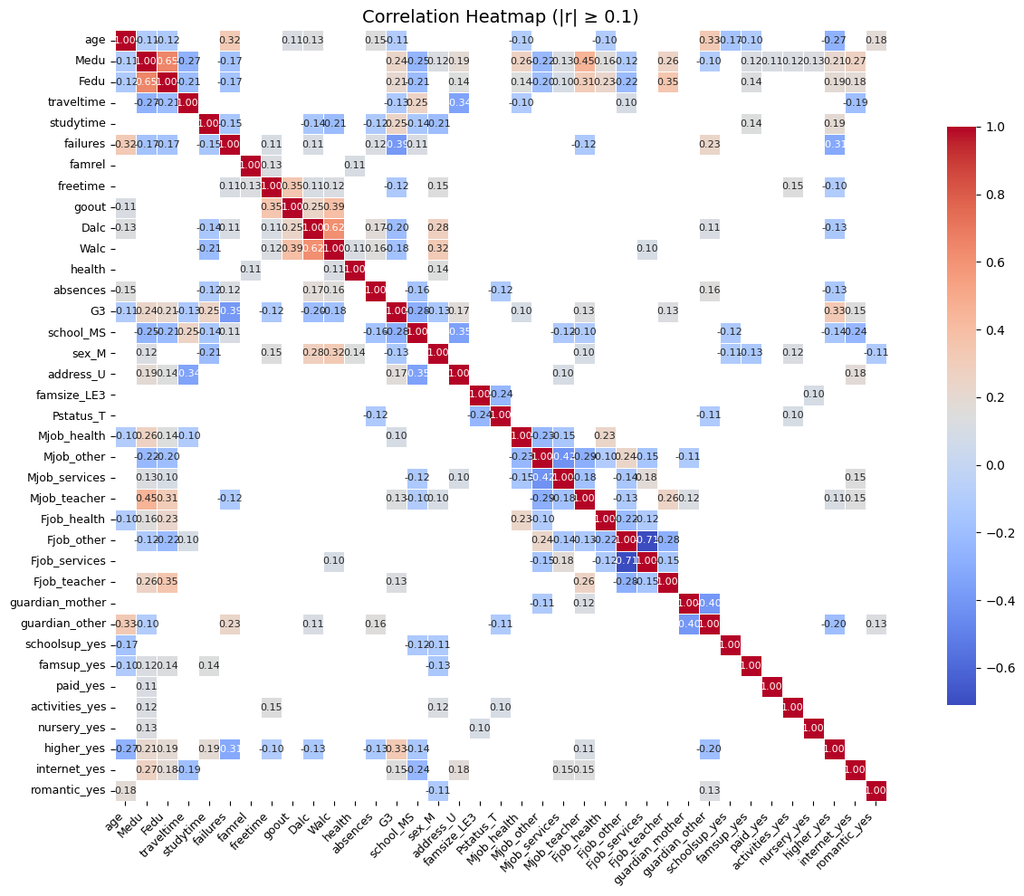

```python
corr = students_encoded.corr(numeric_only=True)

mask = abs(corr) < 0.1
corr = corr.mask(mask)

plt.figure(figsize=(14, 10))
sns.heatmap(
    corr,
    annot=True,
    fmt=".2f",
    cmap="coolwarm",
    linewidths=0.5,
    square=True,
    cbar_kws={"shrink": 0.75},
    annot_kws={"size": 8}
)

plt.title("Correlation Heatmap (|r| ≥ 0.1)", fontsize=14)
plt.xticks(rotation=45, ha="right", fontsize=9)
plt.yticks(rotation=0, fontsize=9)
plt.tight_layout()
plt.show()
```

# Back to your Seats

I will now flatten the parental job features by consolidating all the fragmented Mjob_* and Fjob_* categories into two simple binary fields — Mjob and Fjob.

Each will indicate whether the parent is employed (1) or not (0). This streamlines the dataset and removes the noise introduced by the low-frequency job subcategories.

```python
# father employed if any non-home job column is True
students_encoded['Mjob'] = (
    students_encoded[['Mjob_health', 'Mjob_other', 'Mjob_services', 'Mjob_teacher']]
    .any(axis=1)
).astype(int)

# mother employed if any non-home job column is True
students_encoded['Fjob'] = (
    students_encoded[['Fjob_health', 'Fjob_other', 'Fjob_services', 'Fjob_teacher']]
    .any(axis=1)
).astype(int)
```

```python
job_cols = [c for c in students_encoded.columns if c.startswith('Mjob_') or c.startswith('Fjob_') or c.startswith('guardian')]
students_encoded.drop(columns=job_cols, inplace=True)
students_encoded[['Mjob', 'Fjob']].sum()
```

```
Mjob    514
Fjob    607
dtype: int64
```

# Please Turn to the next Page

And with that done, we’re down to 29 columns from the original 37 — a cleaner, more focused dataset. The noise is trimmed, the redundancy is gone, and what remains should give the model a clearer picture of what actually matters.

```python
students_encoded.shape
```

```
(649, 29)
```

# Now where did I put those glasses?

Quick look at the data to make sure everything worked as expected after dropping the redundant columns. The dataset should now be leaner — fewer columns, no duplicates, and only the features that actually carry weight.

```python
students_encoded.info()
```

```
<class 'pandas.core.frame.DataFrame'>
RangeIndex: 649 entries, 0 to 648
Data columns (total 29 columns):
 #   Column          Non-Null Count  Dtype
---  ------          --------------  -----
 0   age             649 non-null    int64
 1   Medu            649 non-null    int64
 2   Fedu            649 non-null    int64
 3   traveltime      649 non-null    int64
 4   studytime       649 non-null    int64
 5   failures        649 non-null    int64
 6   famrel          649 non-null    int64
 7   freetime        649 non-null    int64
 8   goout           649 non-null    int64
 9   Dalc            649 non-null    int64
```

[output cut: 21 more lines]

# One more thing ..

Now I apply a log transform to absences, and we can see if any lessons were learned. Below is the before and after.

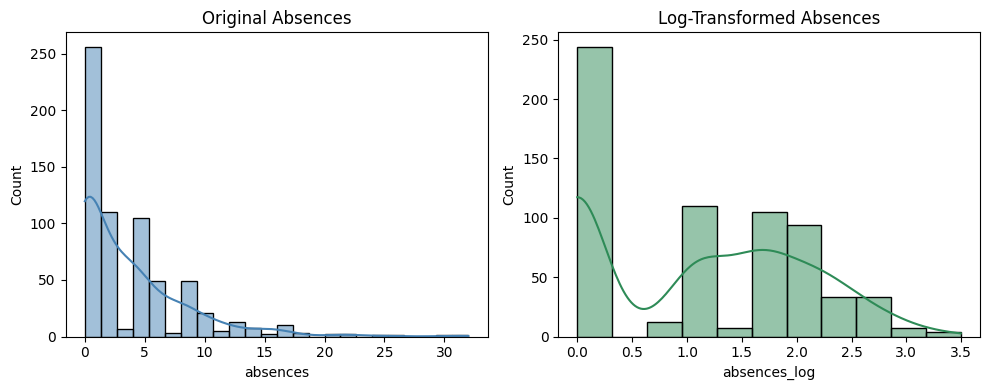

```python
fig, axes = plt.subplots(1, 2, figsize=(10, 4))

# Original distribution
sns.histplot(students_encoded['absences'], ax=axes[0], kde=True, color='steelblue')
axes[0].set_title('Original Absences')

students_encoded['absences_log'] = np.log1p(students_encoded['absences'])

# Log-transform and plot
sns.histplot(students_encoded['absences_log'], ax=axes[1], kde=True, color='seagreen')
axes[1].set_title('Log-Transformed Absences')

plt.tight_layout()
plt.show()

students_encoded.drop(columns=['absences'], inplace=True)
```

# No Copying Your Neighbor's Work!

### Experiment 2: Feature Engineering

It’s the same model, just with cleaner data — so I’ll reuse the previous setup. Let’s see if a little cleanup helps the model learn to study smarter, not harder.

```python
X = students_encoded.drop(columns=['G3'])
y = students_encoded['G3']

X_train, X_test, y_train, y_test = train_test_split(
    X, y, test_size=0.2, random_state=42
)

X_train.shape, X_test.shape, y_train.shape, y_test.shape

linreg = LinearRegression()
linreg.fit(X_train, y_train)

y_pred = linreg.predict(X_test)

r2 = r2_score(y_test, y_pred)
mae = mean_absolute_error(y_test, y_pred)
rmse = root_mean_squared_error(y_test, y_pred)

print(f"R²:   {r2:.3f}")
print(f"MAE:  {mae:.3f}")
print(f"RMSE: {rmse:.3f}")


coefs = pd.Series(linreg.coef_, index=X_train.columns).sort_values(ascending=False)

coefs.head(10), coefs.tail(10)
```

```
R²:   0.209
MAE:  2.071
RMSE: 2.777
```

```
(higher_yes        1.690810
 studytime         0.401416
 internet_yes      0.351865
 Mjob              0.334485
 Fedu              0.251342
 famsize_LE3       0.242626
 activities_yes    0.231804
 address_U         0.179953
 famrel            0.137199
 age               0.134581
 dtype: float64,
 Pstatus_T       -0.171627
 health          -0.199141
 Dalc            -0.335138
 romantic_yes    -0.389092
 sex_M           -0.438898
 paid_yes        -0.479727
 Fjob            -0.669602
 failures        -1.446099
 school_MS       -1.528954
 schoolsup_yes   -1.574059
 dtype: float64)
```

# See Hard Work does Pay Off

Buuuuttttt not by much… Turns out cleaning was the right call — the old model was leaning on noise. After scrubbing things down, the improvement isn’t massive, but it’s real: about a 0.02 bump in R². Not what was expected, but a win nonetheless — and a cleaner one at that.

# Ok, Time for the Honors course

### Experiment 3: Gradient Boosting

If Linear Regression was the kid who plays by the rules, Gradient Boosting is the overachiever who rewrites the test. It builds a series of small, focused models — each one learning from the last one’s mistakes — until the class average turns into an honor roll.

Let’s see if this model can pick up on the real patterns hiding beneath the cleaned data instead of chasing noise.

```
R² Score: 0.265
MAE: 2.008
RMSE: 1.636
```

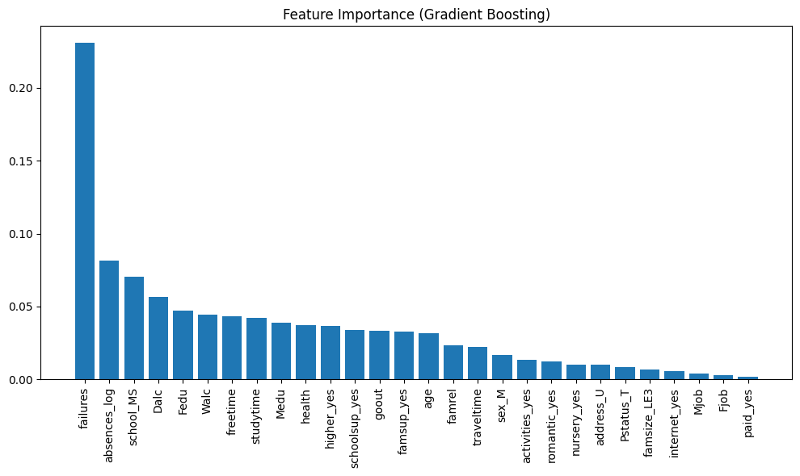

```python
from sklearn.ensemble import GradientBoostingRegressor

df = students_encoded.copy()
X = df.drop(columns=['G3'])
y = df['G3']

X_train, X_test, y_train, y_test = train_test_split(
    X, y, test_size=0.20, random_state=42, stratify=None
)

gbr = GradientBoostingRegressor(
    n_estimators=300,
    learning_rate=0.05,
    max_depth=4,
    min_samples_split=3,
    min_samples_leaf=2,
    random_state=42
)

# Fit model
gbr.fit(X_train, y_train)

# Predictions
y_pred = gbr.predict(X_test)

# Evaluation metrics
r2 = r2_score(y_test, y_pred)
mae = mean_absolute_error(y_test, y_pred)
rmse = np.sqrt(root_mean_squared_error(y_test, y_pred))

print(f"R² Score: {r2:.3f}")
print(f"MAE: {mae:.3f}")
print(f"RMSE: {rmse:.3f}")


importance = gbr.feature_importances_
indices = np.argsort(importance)[::-1]
features = X.columns

plt.figure(figsize=(10,6))
plt.bar(range(len(importance)), importance[indices])
plt.xticks(range(len(importance)), features[indices], rotation=90)
plt.title("Feature Importance (Gradient Boosting)")
plt.tight_layout()
plt.show()
```

# Curve incoming!

Even though performance improved, it’s not by much — we only moved from an R² of 0.20 to 0.26. Still, progress is progress. What’s more interesting is that Gradient Boosting reshuffled the deck: failures emerged as one of the strongest predictors. Looks like the model’s finally catching on that past performance really does predict future results.

# Review

### Impact

This dataset didn’t show any real predictive capability — at least none that I could extract. I suspect it’s mostly self-reported, especially with features like weekday drinking. Self-reports aren’t reliable in my opinion; they depend on people being objective about themselves, and this dataset doesn’t flatter anyone. On the flip side, some may be too humble to admit success.

A more objectively curated dataset — with clear, measurable inputs — might yield better results. Imagine if we could predict student success accurately; that kind of insight could reshape how schools allocate support or identify at-risk students. But there’s a risk, too: models like this could easily reinforce bias or label students unfairly, especially if based on incomplete or unreliable data. Human behavior is messy, emotional, and unpredictable — reducing it to numbers risks missing what actually drives growth and resilience.

In the end, this project reminded me that even data-driven approaches carry responsibility. Predictive models can inform, but they should never define a person’s potential.

# Recess

#### Conclusion

That’s three strikes, and I’m out. After three experiments and minimal improvement, one thing’s clear: predicting student success is complicated. My guess? The dataset simply doesn’t capture the right kind of data for that question — and no one really knows what that “right data” looks like yet. I came in thinking demographic data would be insightful, but both my assumptions and the model’s predictions fell short.

I tried cleaning, transforming, and even removing features to see if the models could uncover real patterns — but the improvements were minor. The Gradient Boosting model handled noise better and showed a slight bump, but not enough to matter.

In the end, I learned that sometimes the model isn’t the problem — the data is. With roughly 20% predictive ability, there just isn’t enough meaningful signal here to draw real conclusions. Maybe fewer but sharper features, or a larger and more reliable dataset, would make a difference. For now, the question of what truly makes a student successful remains unanswered. School’s out.

# References

Cortez, P. & Silva, A. M. G. (2008). “Student Performance” dataset. UCI Machine Learning Repository. DOI: 10.24432/C5TG7T.  
https://archive.ics.uci.edu/dataset/320/student+performance

OpenAI. (2025).ChatGPT[Large language model].OpenAI.  
https://chat.openai.com

# Disclaimer

Portions of the code refinement, data exploration, and narrative structuring were assisted by OpenAI’s ChatGPT (GPT-5). I directed the analysis, made final decisions on preprocessing steps, and selected visualizations, while ChatGPT was used as a learning and drafting tool.